# Pertemuan 6 dan 7 - Forecasting ARIMA

Daily Minimum Temperatures - Data ke-2191 s.d. 2920 (Anggota Nomor 4)

Friska

30 September 2026

# 1 Pendahuluan

Data yang digunakan adalah *Daily Minimum Temperatures* (suhu minimum harian). Total data ada 3650 observasi, dibagi rata untuk 5 anggota (masing-masing 730 data). Bagian **anggota nomor 4** adalah observasi ke-**2191 sampai 2920** (1 Januari 1987 - 30 Desember 1988).

# 2 Persiapan Data

```r
# install.packages(c("forecast", "tseries", "ggplot2"))  # jalankan sekali jika belum ada
library(forecast)
library(tseries)
library(ggplot2)
```

```r
# File data_nomor4.csv harus berada di folder yang sama dengan file .Rmd ini
data <- read.csv("data_nomor4.csv")
data$Date <- as.Date(data$Date)

nrow(data)
```

```
## [1] 730
```

```r
head(data)
```

|  | Date | Temp |
| --- | --- | --- |
| 1 | 1987-01-01 | 12.3 |
| 2 | 1987-01-02 | 13.8 |
| 3 | 1987-01-03 | 15.3 |
| 4 | 1987-01-04 | 15.6 |
| 5 | 1987-01-05 | 16.2 |
| 6 | 1987-01-06 | 16.3 |

```r
tail(data)
```

|  | Date | Temp |
| --- | --- | --- |
| 725 | 1988-12-25 | 15.8 |
| 726 | 1988-12-26 | 9.5 |
| 727 | 1988-12-27 | 12.9 |
| 728 | 1988-12-28 | 12.9 |
| 729 | 1988-12-29 | 14.8 |
| 730 | 1988-12-30 | 14.1 |

```r
summary(data$Temp)
```

```
##    Min. 1st Qu.  Median    Mean 3rd Qu.    Max.
##    1.50    8.80   11.35   11.41   13.90   24.10
```

Data berisi 730 observasi. Kita ubah menjadi objek *time series*.

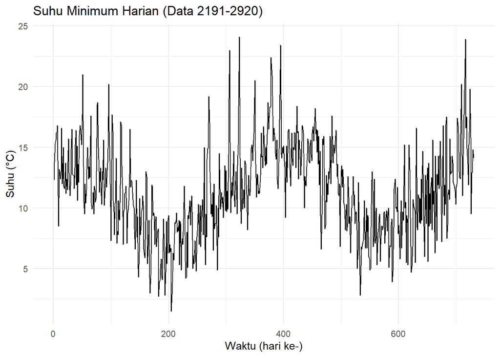

```r
y <- ts(data$Temp, start = 1, frequency = 1)

autoplot(y) +
  labs(title = "Suhu Minimum Harian (Data 2191-2920)",
       x = "Waktu (hari ke-)", y = "Suhu (°C)") +
  theme_minimal()
```

# 3 Pembagian Data Training dan Testing

Data dibagi menjadi data latih (700 hari pertama) dan data uji (30 hari terakhir) untuk mengevaluasi akurasi peramalan.

```r
h <- 30
n <- length(y)
train <- window(y, end = n - h)
test  <- window(y, start = n - h + 1)

length(train); length(test)
```

```
## [1] 700
```

```
## [1] 30
```

# 4 Uji Stasioneritas

```r
adf.test(train)
```

```
##
##  Augmented Dickey-Fuller Test
##
## data:  train
## Dickey-Fuller = -3.7027, Lag order = 8, p-value = 0.02386
## alternative hypothesis: stationary
```

```r
kpss.test(train)
```

```
##
##  KPSS Test for Level Stationarity
##
## data:  train
## KPSS Level = 0.66312, Truncation lag parameter = 6, p-value = 0.0169
```

Hipotesis ADF: H0 = data tidak stasioner. Jika p-value < 0.05, H0 ditolak sehingga data stasioner. (Sebaliknya untuk KPSS: H0 = data stasioner.)

Jumlah diferensiasi yang disarankan:

```r
ndiffs(train)
```

```
## [1] 1
```

# 5 Identifikasi Model (ACF dan PACF)

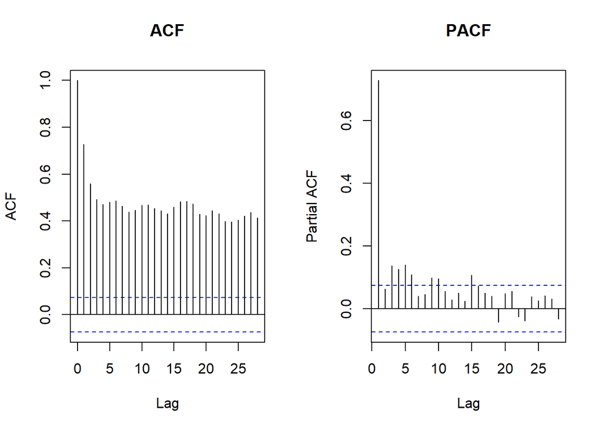

```r
par(mfrow = c(1, 2))
acf(train, main = "ACF")
pacf(train, main = "PACF")
```

```r
par(mfrow = c(1, 1))
```

Pola ACF menurun perlahan (tails off) dan PACF terpotong (cut off) setelah lag tertentu mengindikasikan komponen AR. Kandidat model ditentukan dari plot ini, lalu dibandingkan dengan `auto.arima`.

# 6 Pemodelan ARIMA

```r
fit_auto <- auto.arima(train, stepwise = FALSE, approximation = FALSE)
summary(fit_auto)
```

```
## Series: train
## ARIMA(3,1,2) with drift
##
## Coefficients:
##          ar1      ar2     ar3      ma1     ma2    drift
##       1.5075  -0.6028  0.0756  -1.9368  0.9407  -0.0004
## s.e.  0.0415   0.0647  0.0399   0.0185  0.0184   0.0173
##
## sigma^2 = 5.633:  log likelihood = -1593.81
## AIC=3201.62   AICc=3201.78   BIC=3233.47
##
## Training set error measures:
##                        ME     RMSE      MAE       MPE     MAPE     MASE
## Training set -0.002428224 2.361415 1.846733 -5.452347 19.49736 0.891359
##                       ACF1
## Training set -0.0001459159
```

Beberapa model kandidat sebagai pembanding:

```r
kandidat <- list(
  "ARIMA(1,0,0)" = Arima(train, order = c(1, 0, 0)),
  "ARIMA(2,0,0)" = Arima(train, order = c(2, 0, 0)),
  "ARIMA(1,0,1)" = Arima(train, order = c(1, 0, 1)),
  "ARIMA(2,0,1)" = Arima(train, order = c(2, 0, 1)),
  "ARIMA(1,1,1)" = Arima(train, order = c(1, 1, 1)),
  "auto.arima"   = fit_auto
)

perbandingan <- data.frame(
  Model = names(kandidat),
  AIC   = sapply(kandidat, AIC),
  BIC   = sapply(kandidat, BIC)
)
perbandingan[order(perbandingan$AIC), ]
```

|  | Model | AIC | BIC |
| --- | --- | --- | --- |
| auto.arima | auto.arima | 3201.620 | 3233.467 |
| ARIMA(1,1,1) | ARIMA(1,1,1) | 3207.063 | 3220.712 |
| ARIMA(2,0,1) | ARIMA(2,0,1) | 3212.731 | 3235.486 |
| ARIMA(1,0,1) | ARIMA(1,0,1) | 3275.137 | 3293.342 |
| ARIMA(2,0,0) | ARIMA(2,0,0) | 3277.188 | 3295.392 |
| ARIMA(1,0,0) | ARIMA(1,0,0) | 3278.031 | 3291.684 |

Model terbaik dipilih berdasarkan AIC/BIC terkecil.

```r
best_name <- perbandingan$Model[which.min(perbandingan$AIC)]
fit <- kandidat[[best_name]]
best_name
```

```
## [1] "auto.arima"
```

```r
summary(fit)
```

```
## Series: train
## ARIMA(3,1,2) with drift
##
## Coefficients:
##          ar1      ar2     ar3      ma1     ma2    drift
##       1.5075  -0.6028  0.0756  -1.9368  0.9407  -0.0004
## s.e.  0.0415   0.0647  0.0399   0.0185  0.0184   0.0173
##
## sigma^2 = 5.633:  log likelihood = -1593.81
## AIC=3201.62   AICc=3201.78   BIC=3233.47
##
## Training set error measures:
##                        ME     RMSE      MAE       MPE     MAPE     MASE
## Training set -0.002428224 2.361415 1.846733 -5.452347 19.49736 0.891359
##                       ACF1
## Training set -0.0001459159
```

# 7 Diagnostik Model (Uji Residual)

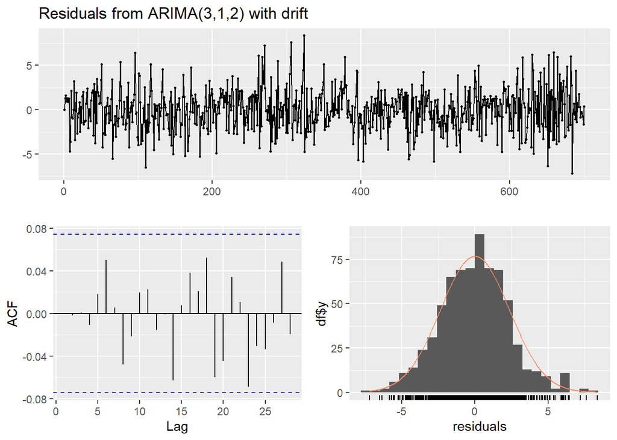

```
##
##  Ljung-Box test
##
## data:  Residuals from ARIMA(3,1,2) with drift
## Q* = 4.3406, df = 5, p-value = 0.5015
##
## Model df: 5.   Total lags used: 10
```

```r
checkresiduals(fit)
```

```r
# Uji Ljung-Box: H0 = residual tidak berautokorelasi (white noise)
df_lb <- length(coef(fit))
Box.test(residuals(fit), lag = 20, type = "Ljung-Box", fitdf = df_lb)
```

```
##
##  Box-Ljung test
##
## data:  residuals(fit)
## X-squared = 15.167, df = 14, p-value = 0.3668
```

```r
# Uji normalitas residual
shapiro.test(as.numeric(residuals(fit)))
```

```
##
##  Shapiro-Wilk normality test
##
## data:  as.numeric(residuals(fit))
## W = 0.99487, p-value = 0.01897
```

Jika p-value Ljung-Box > 0.05 maka residual bersifat white noise, artinya model sudah memadai.

# 8 Forecasting

## 8.1 Peramalan pada Data Uji (30 hari)

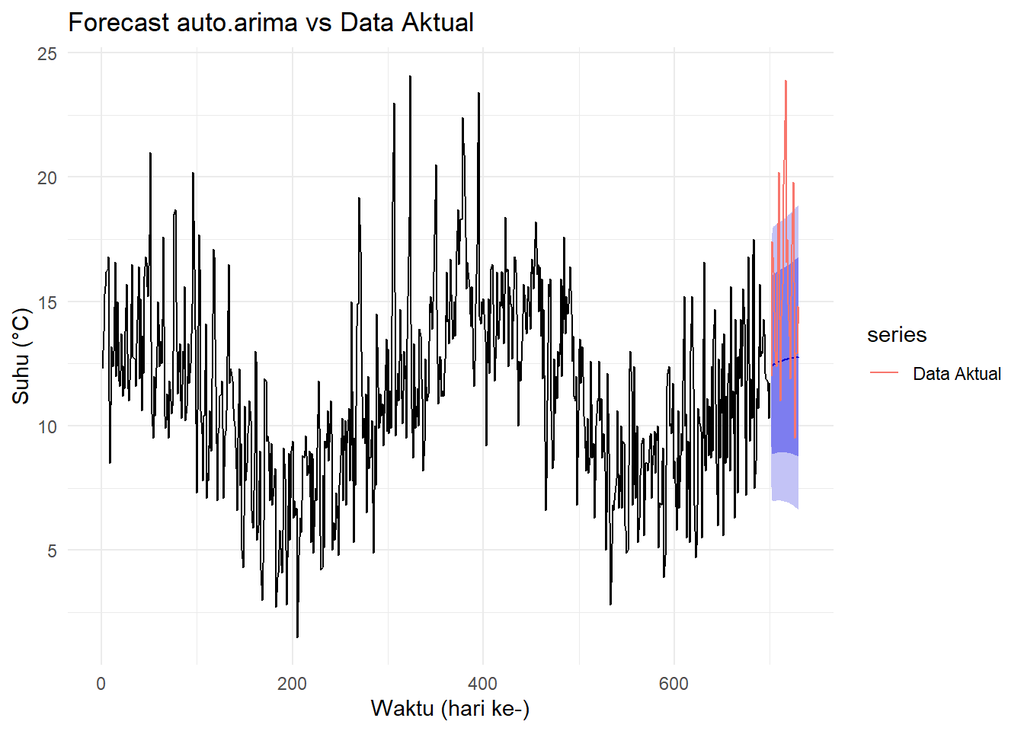

```r
fc <- forecast(fit, h = h)

autoplot(fc) +
  autolayer(test, series = "Data Aktual") +
  labs(title = paste("Forecast", best_name, "vs Data Aktual"),
       x = "Waktu (hari ke-)", y = "Suhu (°C)") +
  theme_minimal()
```

```r
accuracy(fc, test)
```

```
##                        ME     RMSE      MAE       MPE     MAPE     MASE
## Training set -0.002428224 2.361415 1.846733 -5.452347 19.49736 0.891359
## Test set      2.808764271 4.225544 3.211792 14.791672 18.70671 1.550230
##                       ACF1 Theil's U
## Training set -0.0001459159        NA
## Test set      0.4564295207  1.183786
```

## 8.2 Peramalan ke Depan (30 hari setelah data ke-730)

Model dilatih ulang menggunakan seluruh 730 data.

```r
fit_final <- Arima(y, order = arimaorder(fit)[1:3])
fc_final  <- forecast(fit_final, h = 30)
fc_final
```

```
##     Point Forecast    Lo 80    Hi 80    Lo 95    Hi 95
## 731       14.67460 11.58962 17.75957 9.956533 19.39266
## 732       15.02958 11.45051 18.60865 9.555862 20.50329
## 733       15.15143 11.47367 18.82918 9.526786 20.77607
## 734       15.16613 11.46249 18.86978 9.501892 20.83038
## 735       15.14559 11.42865 18.86253 9.461018 20.83015
## 736       15.11839 11.38947 18.84731 9.415503 20.82128
## 737       15.09358 11.35137 18.83580 9.370362 20.81681
## 738       15.07309 11.31573 18.83046 9.326697 20.81949
## 739       15.05670 11.28243 18.83098 9.284443 20.82896
## 740       15.04373 11.25105 18.83641 9.243329 20.84414
## 741       15.03350 11.22121 18.84578 9.203114 20.86388
## 742       15.02542 11.19259 18.85825 9.163617 20.88723
## 743       15.01906 11.16495 18.87316 9.124712 20.91340
## 744       15.01403 11.13810 18.88997 9.086307 20.94176
```

[output cut: 16 more lines]

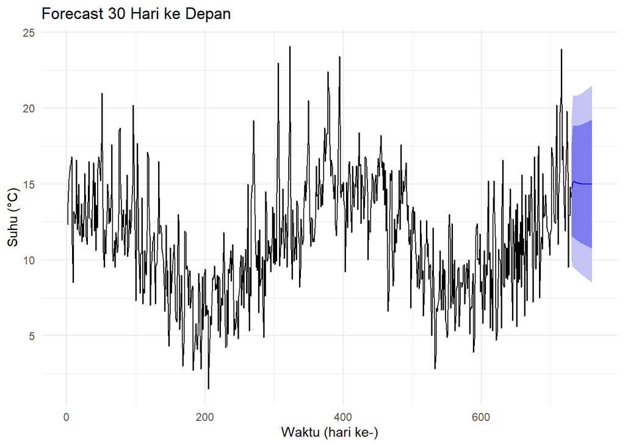

```r
autoplot(fc_final) +
  labs(title = "Forecast 30 Hari ke Depan", x = "Waktu (hari ke-)", y = "Suhu (°C)") +
  theme_minimal()
```

# 9 Kesimpulan

1. Model ARIMA terbaik untuk data suhu minimum harian (observasi 2191-2920) adalah model dengan AIC terkecil pada tabel perbandingan di atas.
2. Uji residual (Ljung-Box) digunakan untuk memastikan model layak dipakai.
3. Akurasi peramalan dilihat dari RMSE, MAE, dan MAPE pada data uji.